# CountClust application on immune scRNAseq data : A demo

Kushal K Dey

7/20/2017

# Contents

## 0.1 Introduction

This is a demo of the results from applying the Grade of Membership model CountClust on Pantaleo single cell RNA-seq data. The data was collected from three HIV- and one HIV+ patient from live cells and TFH cells with two sources of occurrence - Lymph node (LN) and PBMC (peripheral blood mononuclear cell).

In this script, I show the results of applying CountClust on LN+PBMC data for the Live cells for a HIV- patient (TFH146). The detailed results from application of CountClust to TFH cells or pooled TFH and Live cells for other patients are reported in a more detailed report in other scripts.

We look at the TFH146 patient here.

## 0.2 Countclust results

```
## [1] TRUE
```

```
## [1] TRUE
```

```
## [1]   826 16230
```

```
## [1] 16230
```

We fit CountClust model for $K=4$.

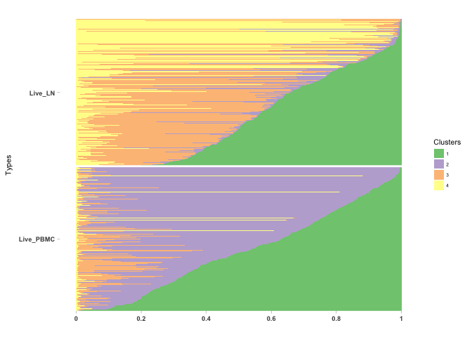

```r
topic_clus_list <- get(load("TFH146/CountClust_Models_filtered.rda"))
PlotCountClust(topic_clus_list[[4]], LiveCells_fac)
```

Each horizontal line in the above plot is a single cell drawn from the TFH146 individual. The cells are grouped into LN and PBMC groups. Note that the first cluster (green) has representation in both the cells from PBMC and the LN cells. On the other hand, the 2nd cluster has high memberships in the PBMC cells and the 3rd cluster has high memberships in some of the the LN cells. The 4th cluster also seems to have high memberships in some of the cells from LN.

The question is can we say anything from these memberships patterns about the cell types of some of these cells. For example, are the cells with high memberships in the yellow cluster (cluster 4) belong to a particular cell type, and the ones with high high memberships in orange cluster belong to another cell type, both of which are present in Lymph nodes?

To answer the question, we use the `ExtractTopFeatures()` function in Countclust to determine the genes that drive these clusters and see if we find any common functionality among the top genes driving each cluster?

## 0.3 Top cluster driving genes

```r
indices <- ExtractTopFeatures(topic_clus_list[[4]]$theta, top_features = 100, method = "poisson", options = "max")
imp_genes <- apply(indices, 1, function(x) return(colnames(counts2)[x]))
```

### 0.3.1 top genes - Cluster 1, K = 4

```r
out <- mygene::queryMany(imp_genes[1:50,1],  scopes="symbol", fields=c("name", "summary"), species="human");
```

```
## Finished
## Pass returnall=TRUE to return lists of duplicate or missing query terms.
```

```r
cbind.data.frame(out$name)
```

```
##                                                                    out$name
## 1                                                    interleukin 7 receptor
## 2                                                            interleukin 32
## 3                                           S100 calcium binding protein A6
## 4                                           cytochrome c oxidase subunit 6C
## 5                                              GTPase, IMAP family member 7
## 6                                                              CD2 molecule
## 7                                  NDUFA4, mitochondrial complex associated
## 8                                                   Y-box binding protein 1
## 9                                        signal sequence receptor subunit 4
## 10                                           C-C motif chemokine receptor 7
## 11                                                               selectin L
## 12                                           proteasome activator subunit 1
## 13                                  RNA binding motif (RNP1, RRM) protein 3
## 14                                                               galectin 1
```

[output cut: 36 more lines]

### 0.3.2 top genes - Cluster 2, K = 4

```r
out <- mygene::queryMany(imp_genes[1:50,2],  scopes="symbol", fields=c("name", "summary"), species="human");
```

```
## Finished
## Pass returnall=TRUE to return lists of duplicate or missing query terms.
```

```r
cbind.data.frame(out$name)
```

```
##                                                       out$name
## 1                                 C-C motif chemokine ligand 5
## 2                                                   granulysin
## 3                                                   granzyme B
## 4                        natural killer cell granule protein 7
## 5                                    C-X9-C motif containing 1
## 6                                         beta-2-microglobulin
## 7                                         beta-2-microglobulin
## 8                                         beta-2-microglobulin
## 9                                                   cystatin F
## 10                         killer cell lectin like receptor D1
## 11                                                  perforin 1
## 12                     inhibitor of DNA binding 2, HLH protein
## 13                                                  granzyme H
## 14                      C-type lectin domain family 2 member B
```

[output cut: 39 more lines]

### 0.3.3 top genes - Cluster 3, K = 4

```r
out <- mygene::queryMany(imp_genes[1:50,3],  scopes="symbol", fields=c("name", "summary"), species="human");
```

```
## Finished
## Pass returnall=TRUE to return lists of duplicate or missing query terms.
```

```r
cbind.data.frame(out$name)
```

```
##                                                                       out$name
## 1                       Metastasis associated lung adenocarcinoma transcript 1
## 2  metastasis associated lung adenocarcinoma transcript 1 (non-protein coding)
## 3                                heat shock protein family A (Hsp70) member 1B
## 4                                heat shock protein family A (Hsp70) member 1A
## 5                                                                vault RNA 1-3
## 6                                                  TBC1 domain family member 1
## 7                             DnaJ heat shock protein family (Hsp40) member B1
## 8                                                                         <NA>
## 9                                              small nucleolar RNA, C/D box 89
## 10                                                                        <NA>
## 11                       Jun proto-oncogene, AP-1 transcription factor subunit
## 12                                         regulator of G protein signaling 10
## 13                                                                       titin
## 14                                heat shock protein family A (Hsp70) member 6
```

[output cut: 41 more lines]

### 0.3.4 top genes - Cluster 4, K = 4

```r
out <- mygene::queryMany(imp_genes[1:50,4],  scopes="symbol", fields=c("name", "summary"), species="human");
```

```
## Finished
## Pass returnall=TRUE to return lists of duplicate or missing query terms.
```

```r
#cbind.data.frame(out$name)
cbind.data.frame(out$name)
```

```
##                                                  out$name
## 1    major histocompatibility complex, class II, DR alpha
## 2                          membrane spanning 4-domains A1
## 3                                           vault RNA 1-1
## 4                                        lymphotoxin beta
## 5                           immunoglobulin kappa constant
## 6                           immunoglobulin kappa constant
## 7                                                    <NA>
## 8                   immunoglobulin heavy constant alpha 1
## 9                   immunoglobulin heavy constant alpha 1
## 10                  immunoglobulin heavy constant alpha 1
## 11                                          CD74 molecule
## 12         B-cell scaffold protein with ankyrin repeats 1
## 13 major histocompatibility complex, class II, DQ alpha 1
## 14  major histocompatibility complex, class II, DQ beta 1
```

[output cut: 47 more lines]

## 0.4 Expression patterns of top driving genes

To validate that these genes are indeed driving the clusters, we plot the expression patterns of the genes for the different clusters corresponding to the LN and PBMC grouping.

### 0.4.1 First cluster genes (K=4)

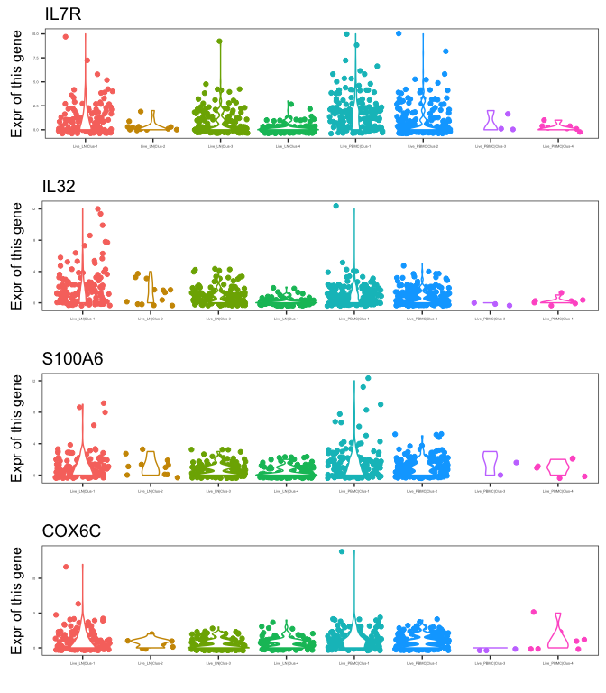

### 0.4.2 Second cluster genes (K=4)

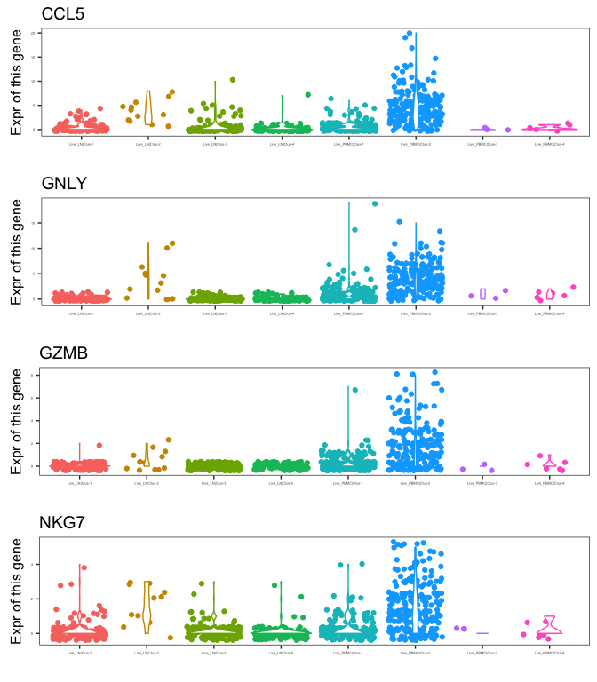

### 0.4.3 Third cluster genes (K=4)

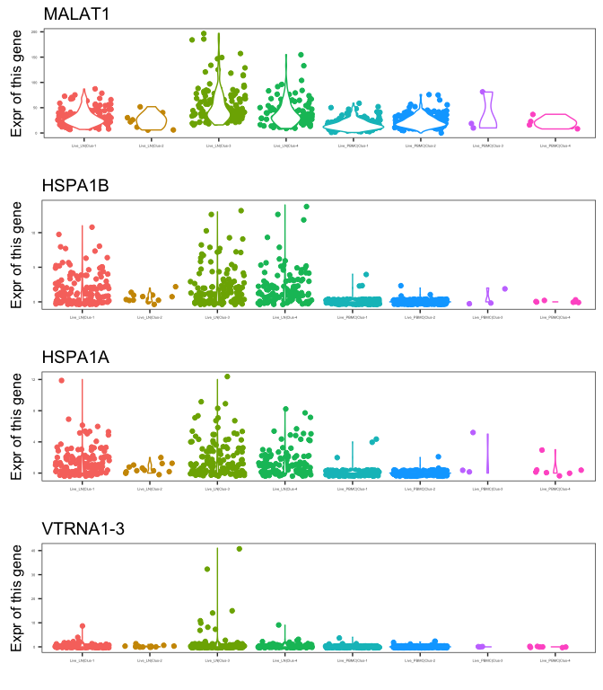

### 0.4.4 Fourth cluster genes (K=4)

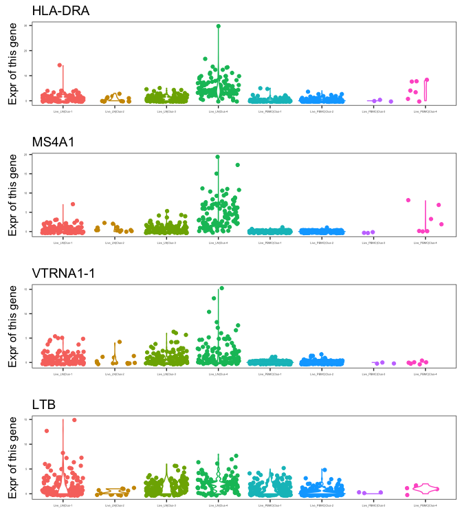